# Project 2 - Part 1: Crime Data from 2020 - Present in Los Angeles

**Name:** Emmanuel Mokua  
**ID:** @03085667 **Title:** Crime Data Analysis from 2020 to Present

## Introduction

**References:**  
https://catalog.data.gov/dataset/crime-data-from-2020-to-present

```python
import pandas as pd
import numpy as np
import matplotlib.pyplot as plt
import seaborn as sns
```

#### Loading the Dataset

```python
df = pd.read_csv("Crime_Data_LA.csv")
```

## SECTION 1: DATASET OVERVIEW AND STRUCTURE

#### Shape of the dataset

```python
df.shape
```

```
(1005149, 28)
```

#### First 15 rows of the dataframe

```python
df.head(15)
```

|  | DR_NO | Date Rptd | DATE OCC | TIME OCC | AREA | AREA NAME | Rpt Dist No | Part 1-2 | Crm Cd | Crm Cd Desc | ... | Status | Status Desc | Crm Cd 1 | Crm Cd 2 | Crm Cd 3 | Crm Cd 4 | LOCATION | Cross Street | LAT | LON |
| --- | --- | --- | --- | --- | --- | --- | --- | --- | --- | --- | --- | --- | --- | --- | --- | --- | --- | --- | --- | --- | --- |
| 0 | 190326475 | 03/01/2020 12:00:00 AM | 03/01/2020 12:00:00 AM | 2130 | 7 | Wilshire | 784 | 1 | 510 | VEHICLE - STOLEN | ... | AA | Adult Arrest | 510.0 | 998.0 | NaN | NaN | 1900 S LONGWOOD AV | NaN | 34.0375 | -118.3506 |
| 1 | 200106753 | 02/09/2020 12:00:00 AM | 02/08/2020 12:00:00 AM | 1800 | 1 | Central | 182 | 1 | 330 | BURGLARY FROM VEHICLE | ... | IC | Invest Cont | 330.0 | 998.0 | NaN | NaN | 1000 S FLOWER ST | NaN | 34.0444 | -118.2628 |
| 2 | 200320258 | 11/11/2020 12:00:00 AM | 11/04/2020 12:00:00 AM | 1700 | 3 | Southwest | 356 | 1 | 480 | BIKE - STOLEN | ... | IC | Invest Cont | 480.0 | NaN | NaN | NaN | 1400 W 37TH ST | NaN | 34.0210 | -118.3002 |
| 3 | 200907217 | 05/10/2023 12:00:00 AM | 03/10/2020 12:00:00 AM | 2037 | 9 | Van Nuys | 964 | 1 | 343 | SHOPLIFTING-GRAND THEFT ($950.01 & OVER) | ... | IC | Invest Cont | 343.0 | NaN | NaN | NaN | 14000 RIVERSIDE DR | NaN | 34.1576 | -118.4387 |
| 4 | 200412582 | 09/09/2020 12:00:00 AM | 09/09/2020 12:00:00 AM | 630 | 4 | Hollenbeck | 413 | 1 | 510 | VEHICLE - STOLEN | ... | IC | Invest Cont | 510.0 | NaN | NaN | NaN | 200 E AVENUE 28 | NaN | 34.0820 | -118.2130 |
| 5 | 200209713 | 05/03/2020 12:00:00 AM | 05/02/2020 12:00:00 AM | 1800 | 2 | Rampart | 245 | 1 | 510 | VEHICLE - STOLEN | ... | IC | Invest Cont | 510.0 | NaN | NaN | NaN | 2500 W 4TH ST | NaN | 34.0642 | -118.2771 |
| 6 | 200200759 | 07/07/2020 12:00:00 AM | 07/07/2020 12:00:00 AM | 1340 | 2 | Rampart | 265 | 1 | 648 | ARSON | ... | IC | Invest Cont | 648.0 | 998.0 | NaN | NaN | JAMES M WOOD | ALVARADO | 34.0536 | -118.2788 |
| 7 | 201308739 | 03/27/2020 12:00:00 AM | 03/27/2020 12:00:00 AM | 1210 | 13 | Newton | 1333 | 1 | 510 | VEHICLE - STOLEN | ... | IC | Invest Cont | 510.0 | NaN | NaN | NaN | 3200 S SAN PEDRO ST | NaN | 34.0170 | -118.2643 |
| 8 | 201112065 | 07/31/2020 12:00:00 AM | 07/30/2020 12:00:00 AM | 2030 | 11 | Northeast | 1161 | 1 | 510 | VEHICLE - STOLEN | ... | AA | Adult Arrest | 510.0 | NaN | NaN | NaN | KENMORE ST | FOUNTAIN | 34.0953 | -118.2974 |
| 9 | 200121929 | 12/04/2020 12:00:00 AM | 12/03/2020 12:00:00 AM | 2300 | 1 | Central | 105 | 1 | 510 | VEHICLE - STOLEN | ... | IC | Invest Cont | 510.0 | NaN | NaN | NaN | 400 SOLANO AV | NaN | 34.0710 | -118.2302 |
| 10 | 201215394 | 06/26/2020 12:00:00 AM | 06/25/2020 12:00:00 AM | 2200 | 12 | 77th Street | 1259 | 1 | 510 | VEHICLE - STOLEN | ... | IC | Invest Cont | 510.0 | NaN | NaN | NaN | FLORENCE | WADSWORTH | 33.9747 | -118.2587 |
| 11 | 200406391 | 03/02/2020 12:00:00 AM | 03/01/2020 12:00:00 AM | 1430 | 4 | Hollenbeck | 407 | 1 | 310 | BURGLARY | ... | IC | Invest Cont | 310.0 | NaN | NaN | NaN | 4500 HUNTINGTON DR | NaN | 34.0881 | -118.1877 |
| 12 | 200114396 | 07/06/2020 12:00:00 AM | 07/04/2020 12:00:00 AM | 100 | 1 | Central | 157 | 1 | 510 | VEHICLE - STOLEN | ... | IC | Invest Cont | 510.0 | NaN | NaN | NaN | 6TH ST | CROCKER | 34.0423 | -118.2453 |
| 13 | 200912561 | 07/20/2020 12:00:00 AM | 07/20/2020 12:00:00 AM | 700 | 9 | Van Nuys | 937 | 1 | 510 | VEHICLE - STOLEN | ... | IC | Invest Cont | 510.0 | NaN | NaN | NaN | BESSEMER | RANCHITO | 34.1812 | -118.4356 |
| 14 | 200207955 | 03/19/2020 12:00:00 AM | 03/19/2020 12:00:00 AM | 130 | 2 | Rampart | 236 | 1 | 510 | VEHICLE - STOLEN | ... | IC | Invest Cont | 510.0 | NaN | NaN | NaN | 1900 MIRAMAR ST | NaN | 34.0632 | -118.2693 |

15 rows × 28 columns

#### Last 15 rows of the dataframe

```python
df.tail(15)
```

|  | DR_NO | Date Rptd | DATE OCC | TIME OCC | AREA | AREA NAME | Rpt Dist No | Part 1-2 | Crm Cd | Crm Cd Desc | ... | Status | Status Desc | Crm Cd 1 | Crm Cd 2 | Crm Cd 3 | Crm Cd 4 | LOCATION | Cross Street | LAT | LON |
| --- | --- | --- | --- | --- | --- | --- | --- | --- | --- | --- | --- | --- | --- | --- | --- | --- | --- | --- | --- | --- | --- |
| 1005134 | 250304059 | 01/16/2025 12:00:00 AM | 01/16/2025 12:00:00 AM | 1200 | 3 | Southwest | 338 | 1 | 522 | VEHICLE, STOLEN - OTHER (MOTORIZED SCOOTERS, B... | ... | IC | Invest Cont | 522.0 | NaN | NaN | NaN | 3100 MCCLINTOCK AV | NaN | 34.0274 | -118.2850 |
| 1005135 | 250304198 | 02/19/2025 12:00:00 AM | 02/19/2025 12:00:00 AM | 1100 | 3 | Southwest | 358 | 1 | 510 | VEHICLE - STOLEN | ... | IC | Invest Cont | 510.0 | NaN | NaN | NaN | 800 CHILDS WY | NaN | 34.0203 | -118.2852 |
| 1005136 | 250304148 | 02/08/2025 12:00:00 AM | 02/06/2025 12:00:00 AM | 2215 | 3 | Southwest | 325 | 1 | 522 | VEHICLE, STOLEN - OTHER (MOTORIZED SCOOTERS, B... | ... | IC | Invest Cont | 522.0 | NaN | NaN | NaN | 2600 S CATALINA ST | NaN | 34.0328 | -118.2942 |
| 1005137 | 251304095 | 01/31/2025 12:00:00 AM | 01/30/2025 12:00:00 AM | 1554 | 13 | Newton | 1372 | 2 | 850 | INDECENT EXPOSURE | ... | IC | Invest Cont | 850.0 | NaN | NaN | NaN | 300 E 53RD ST | NaN | 33.9942 | -118.2701 |
| 1005138 | 250304031 | 01/07/2025 12:00:00 AM | 01/02/2025 12:00:00 AM | 1832 | 3 | Southwest | 312 | 1 | 442 | SHOPLIFTING - PETTY THEFT ($950 & UNDER) | ... | IC | Invest Cont | 442.0 | NaN | NaN | NaN | 5100 W JEFFERSON BL | NaN | 34.0255 | -118.3549 |
| 1005139 | 250504138 | 02/10/2025 12:00:00 AM | 02/06/2025 12:00:00 AM | 30 | 5 | Harbor | 523 | 1 | 341 | THEFT-GRAND ($950.01 & OVER)EXCPT,GUNS,FOWL,LI... | ... | IC | Invest Cont | 341.0 | NaN | NaN | NaN | 2000 JOHN S GIBSON BL | NaN | 33.7566 | -118.2896 |
| 1005140 | 251004092 | 01/25/2025 12:00:00 AM | 01/24/2025 12:00:00 AM | 1240 | 10 | West Valley | 1008 | 1 | 331 | THEFT FROM MOTOR VEHICLE - GRAND ($950.01 AND ... | ... | IC | Invest Cont | 331.0 | NaN | NaN | NaN | 7600 WOODLEY AV | NaN | 34.2085 | -118.4837 |
| 1005141 | 251704066 | 01/17/2025 12:00:00 AM | 01/17/2025 12:00:00 AM | 1600 | 17 | Devonshire | 1774 | 2 | 624 | BATTERY - SIMPLE ASSAULT | ... | IC | Invest Cont | 624.0 | NaN | NaN | NaN | 9600 ZELZAH AV | NaN | 34.2450 | -118.5233 |
| 1005142 | 251904184 | 03/03/2025 12:00:00 AM | 03/03/2025 12:00:00 AM | 845 | 19 | Mission | 1962 | 1 | 231 | ASSAULT WITH DEADLY WEAPON ON POLICE OFFICER | ... | IC | Invest Cont | 231.0 | 998.0 | NaN | NaN | 15300 PLUMMER ST | NaN | 34.2428 | -118.4653 |
| 1005143 | 250304184 | 02/18/2025 12:00:00 AM | 02/14/2025 12:00:00 AM | 1200 | 3 | Southwest | 328 | 1 | 510 | VEHICLE - STOLEN | ... | IC | Invest Cont | 510.0 | NaN | NaN | NaN | 700 W 28TH ST | NaN | 34.0270 | -118.2794 |
| 1005144 | 252104053 | 01/19/2025 12:00:00 AM | 01/17/2025 12:00:00 AM | 1530 | 21 | Topanga | 2114 | 1 | 341 | THEFT-GRAND ($950.01 & OVER)EXCPT,GUNS,FOWL,LI... | ... | IC | Invest Cont | 341.0 | NaN | NaN | NaN | 22200 ELKWOOD ST | NaN | 34.2128 | -118.6103 |
| 1005145 | 250304214 | 02/23/2025 12:00:00 AM | 02/21/2025 12:00:00 AM | 1530 | 3 | Southwest | 358 | 1 | 510 | VEHICLE - STOLEN | ... | IC | Invest Cont | 510.0 | NaN | NaN | NaN | 3600 MCCLINTOCK AV | NaN | 34.0212 | -118.2895 |
| 1005146 | 250304203 | 02/20/2025 12:00:00 AM | 02/13/2025 12:00:00 AM | 2100 | 3 | Southwest | 325 | 1 | 522 | VEHICLE, STOLEN - OTHER (MOTORIZED SCOOTERS, B... | ... | IC | Invest Cont | 522.0 | NaN | NaN | NaN | 2600 ELLENDALE PL | NaN | 34.0307 | -118.2923 |
| 1005147 | 250504051 | 01/14/2025 12:00:00 AM | 01/14/2025 12:00:00 AM | 1250 | 5 | Harbor | 509 | 1 | 210 | ROBBERY | ... | IC | Invest Cont | 210.0 | NaN | NaN | NaN | 24300 WESTERN AV | NaN | 33.8046 | -118.3074 |
| 1005148 | 251604136 | 02/27/2025 12:00:00 AM | 02/27/2025 12:00:00 AM | 1550 | 16 | Foothill | 1664 | 1 | 510 | VEHICLE - STOLEN | ... | AA | Adult Arrest | 510.0 | NaN | NaN | NaN | 11900 SHELDON ST | NaN | 34.2404 | -118.3922 |

15 rows × 28 columns

#### General information of the dataframe

```python
df.info()
```

```
<class 'pandas.core.frame.DataFrame'>
RangeIndex: 1005149 entries, 0 to 1005148
Data columns (total 28 columns):
 #   Column          Non-Null Count    Dtype
---  ------          --------------    -----
 0   DR_NO           1005149 non-null  int64
 1   Date Rptd       1005149 non-null  object
 2   DATE OCC        1005149 non-null  object
 3   TIME OCC        1005149 non-null  int64
 4   AREA            1005149 non-null  int64
 5   AREA NAME       1005149 non-null  object
 6   Rpt Dist No     1005149 non-null  int64
 7   Part 1-2        1005149 non-null  int64
 8   Crm Cd          1005149 non-null  int64
 9   Crm Cd Desc     1005149 non-null  object
```

[output cut: 20 more lines]

#### Variable types of the dataframe columns

```python
print(df.dtypes)
```

```
DR_NO               int64
Date Rptd          object
DATE OCC           object
TIME OCC            int64
AREA                int64
AREA NAME          object
Rpt Dist No         int64
Part 1-2            int64
Crm Cd              int64
Crm Cd Desc        object
Mocodes            object
Vict Age            int64
Vict Sex           object
Vict Descent       object
Premis Cd         float64
Premis Desc        object
Weapon Used Cd    float64
Weapon Desc        object
Status             object
Status Desc        object
Crm Cd 1          float64
Crm Cd 2          float64
Crm Cd 3          float64
Crm Cd 4          float64
LOCATION           object
Cross Street       object
LAT               float64
LON               float64
dtype: object
```

#### Identifying missing values

```python
df.isnull().sum()
```

```
DR_NO                   0
Date Rptd               0
DATE OCC                0
TIME OCC                0
AREA                    0
AREA NAME               0
Rpt Dist No             0
Part 1-2                0
Crm Cd                  0
Crm Cd Desc             0
Mocodes            151741
Vict Age                0
Vict Sex           144765
Vict Descent       144777
Premis Cd              16
Premis Desc           588
Weapon Used Cd     677885
Weapon Desc        677885
Status                  1
Status Desc             0
Crm Cd 1               11
Crm Cd 2           935996
Crm Cd 3          1002835
Crm Cd 4          1005085
LOCATION                0
Cross Street       850909
LAT                     0
LON                     0
dtype: int64
```

Here is how I would handle the missing values for each column with missing data:

- Mocodes (object, 151,741 missing): I’ll fill these with "Unknown" since it’s categorical.
- Vict Sex (object, 144,765 missing) & Vict Descent (object, 144,777 missing): I plan to impute these with the mode.
- Premis Cd (float64, 16 missing): I will drop these few rows.
- Premis Desc (object, 588 missing): I will drop these few rows.
- Weapon Used Cd (float64, 677,885 missing) & Weapon Desc (object, 677,885 missing): I plan to fill them with "No Weapon".
- Status (object, 1 missing): I will impute this using the mode.
- Crm Cd 1 (float64, 11 missing): I plan to fill these with the mode.
- Crm Cd 2, Crm Cd 3, Crm Cd 4 (high missing values): I will impute with a placeholder or drop these columns since they might lack value.
- Cross Street (object, 850,909 missing): I’ll replace missing entries with "N/A".

#### Cleaning the dataset

```python
# Fill missing values in 'Mocodes' with "Unknown"
df['Mocodes'] = df['Mocodes'].fillna("Unknown")

# For 'Vict Sex' and 'Vict Descent', fill missing values with the mode
mode_vict_sex = df['Vict Sex'].mode()[0]
df['Vict Sex'] = df['Vict Sex'].fillna(mode_vict_sex)

mode_vict_descent = df['Vict Descent'].mode()[0]
df['Vict Descent'] = df['Vict Descent'].fillna(mode_vict_descent)

# Drop rows where 'Premis Cd' is missing (16 rows)
df = df.dropna(subset=['Premis Cd'])

# Drop rows where 'Premis Desc' is missing (588 rows)
df = df.dropna(subset=['Premis Desc'])

# For 'Weapon Used Cd' and 'Weapon Desc', fill missing values with "No Weapon"
# Note: 'Weapon Used Cd' is numeric, so filling with a string may require type conversion later if needed.
df['Weapon Used Cd'] = df['Weapon Used Cd'].fillna("No Weapon")
df['Weapon Desc'] = df['Weapon Desc'].fillna("No Weapon")

# For 'Status', fill missing values using the mode
mode_status = df['Status'].mode()[0]
df['Status'] = df['Status'].fillna(mode_status)

# For 'Crm Cd 1', fill missing values with its mode
mode_crm_cd1 = df['Crm Cd 1'].mode()[0]
df['Crm Cd 1'] = df['Crm Cd 1'].fillna(mode_crm_cd1)

# For 'Crm Cd 2', 'Crm Cd 3', and 'Crm Cd 4', drop these columns due to high missing values
df = df.drop(columns=['Crm Cd 2', 'Crm Cd 3', 'Crm Cd 4'])
df = df[df["Vict Age"] > 0]

# For 'Cross Street', replace missing entries with "N/A"
df['Cross Street'] = df['Cross Street'].fillna("N/A")

# Save a copy of the cleaned dataset
df_cleaned = df.copy()

# Export the cleaned dataset to a CSV file without the index
df_cleaned.to_csv('Crime_Data_Cleaned.csv', index=False)
```

## SECTION 2: DATA CLEANING & INDEXING

```python
duplicates = df_cleaned.duplicated().sum()
print("Number of duplicate rows:", duplicates)
```

```
Number of duplicate rows: 0
```

#### DataFrame filtering using logival conditions

```python
# Filtering using a logical condition based on a victim's sex.
male_victim = df_cleaned[df_cleaned['Vict Sex'] == 'M']
print("Rows where the victim is Male:", male_victim.shape)

# Filtering data for a specific area (in this case the'Southwest').
southwest_area_df = df_cleaned[df_cleaned['AREA NAME'] == 'Southwest']
print("Rows where AREA NAME is 'Southwest':", southwest_area_df.shape)
```

[output not shown]

## SECTION 3: DESCRIPTIVE STATISTICS

```python
df_cleaned[['TIME OCC', 'Vict Age']].describe()
```

[output not shown]

One interesting insight is that the TIME OCC values range from as early as 00:01 to as late as 23:59, but the median is around 2:20 PM. This suggests that while crimes occur throughout the day, a significant portion tends to happen in the early-to-mid afternoon.

#### Getting value counts of two categorical columns

```python
df_new = df_cleaned.copy()
```

```python
df_new['Crm Cd Desc'].value_counts()
```

```
Crm Cd Desc
BATTERY - SIMPLE ASSAULT                          73882
BURGLARY FROM VEHICLE                             61559
THEFT OF IDENTITY                                 61349
ASSAULT WITH DEADLY WEAPON, AGGRAVATED ASSAULT    51477
THEFT PLAIN - PETTY ($950 & UNDER)                46922
                                                  ...
INCITING A RIOT                                       2
LYNCHING - ATTEMPTED                                  1
DISHONEST EMPLOYEE ATTEMPTED THEFT                    1
TRAIN WRECKING                                        1
DRUNK ROLL - ATTEMPT                                  1
Name: count, Length: 138, dtype: int64
```

```python
df_new['Premis Desc'].value_counts()
```

```
Premis Desc
STREET                                          261374
SINGLE FAMILY DWELLING                          163656
MULTI-UNIT DWELLING (APARTMENT, DUPLEX, ETC)    119011
PARKING LOT                                      69161
OTHER BUSINESS                                   47649
                                                 ...
MTA - SILVER LINE - LAC/USC MEDICAL CENTER           2
DEPT OF DEFENSE FACILITY                             2
HORSE RACING/SANTA ANITA PARK*                       2
MTA - SILVER LINE - DOWNTOWN STREET STOPS            2
TRAM/STREETCAR(BOXLIKE WAG ON RAILS)*                1
Name: count, Length: 306, dtype: int64
```

#### Summary of location statistics

```python
# Group by 'Crm Cd Desc' and calculate the mean of the latitude and longitude
print("\nMean 'LAT' by 'Premis Desc':")
df_new.groupby('Premis Desc')['LAT'].mean()
print("\nMean 'LON' by 'Premis Desc':")
df_new.groupby('Premis Desc')['LON'].mean()
```

```
Mean 'LAT' by 'Premis Desc':

Mean 'LON' by 'Premis Desc':
```

```
Premis Desc
7TH AND METRO CENTER (NOT LINE SPECIFIC)   -117.514186
ABANDONED BUILDING ABANDONED HOUSE         -117.995509
ABATEMENT LOCATION                         -118.359440
ABORTION CLINIC/ABORTION FACILITY*         -118.342500
AIRCRAFT                                   -118.367690
                                               ...
VISION CARE FACILITY*                      -118.442497
WAREHOUSE                                  -118.314449
WATER FACILITY                             -111.022050
WEBSITE                                    -118.175609
YARD (RESIDENTIAL/BUSINESS)                -117.890344
Name: LON, Length: 304, dtype: float64
```

## SECTION 4: OBSERVATIONS & QUESTIONS

```python
print("Observations:")
print("1. Crimes most likely occur at around 2PM.")
print("2. The presence of missing values in several columns shows that further data cleaning or imputation will be needed.")
```

```
Observations:
1. Crimes most likely occur at around 2PM.
2. The presence of missing values in several columns shows that further data cleaning or imputation will be needed.
```

#### Questions to explore further

```python
print("Questions to Explore Further:")
print("1. How do crime trends vary over time (a month-to-month analysis)?")
print("2. What is the spatial distribution of different crime types across neighborhoods in LA?")
```

```
Questions to Explore Further:
1. How do crime trends vary over time (a month-to-month analysis)?
2. What is the spatial distribution of different crime types across neighborhoods in LA?
```

#### Conclusion

In this project, I performed data wrangling and descriptive statistical analysis on a crime dataset spanning from 2020 to the present in Los Angeles. The key steps included:

- Exploring the dataset structure and identifying variable types
- Checking and handling missing values and duplicates
- Applying filtering techniques and grouping operations to extract insights
- Highlighting observations and formulating questions for further analysis in Part 2 of the project

**Key Takeaways:**

- Crimes occur typically around 2PM.
- Some columns require additional imputation due to missing values.

**Next Steps for Part 2:** Future work will involve using visualizations to explore trends and patterns in the crime data.

**Source:** https://catalog.data.gov/dataset/crime-data-from-2020-to-present

```python
df_new.head(10)
```

|  | DR_NO | Date Rptd | DATE OCC | TIME OCC | AREA | AREA NAME | Rpt Dist No | Part 1-2 | Crm Cd | Crm Cd Desc | ... | Premis Desc | Weapon Used Cd | Weapon Desc | Status | Status Desc | Crm Cd 1 | LOCATION | Cross Street | LAT | LON |
| --- | --- | --- | --- | --- | --- | --- | --- | --- | --- | --- | --- | --- | --- | --- | --- | --- | --- | --- | --- | --- | --- |
| 1 | 200106753 | 02/09/2020 12:00:00 AM | 02/08/2020 12:00:00 AM | 1800 | 1 | Central | 182 | 1 | 330 | BURGLARY FROM VEHICLE | ... | BUS STOP/LAYOVER (ALSO QUERY 124) | No Weapon | No Weapon | IC | Invest Cont | 330.0 | 1000 S FLOWER ST | N/A | 34.0444 | -118.2628 |
| 2 | 200320258 | 11/11/2020 12:00:00 AM | 11/04/2020 12:00:00 AM | 1700 | 3 | Southwest | 356 | 1 | 480 | BIKE - STOLEN | ... | MULTI-UNIT DWELLING (APARTMENT, DUPLEX, ETC) | No Weapon | No Weapon | IC | Invest Cont | 480.0 | 1400 W 37TH ST | N/A | 34.0210 | -118.3002 |
| 3 | 200907217 | 05/10/2023 12:00:00 AM | 03/10/2020 12:00:00 AM | 2037 | 9 | Van Nuys | 964 | 1 | 343 | SHOPLIFTING-GRAND THEFT ($950.01 & OVER) | ... | CLOTHING STORE | No Weapon | No Weapon | IC | Invest Cont | 343.0 | 14000 RIVERSIDE DR | N/A | 34.1576 | -118.4387 |
| 11 | 200406391 | 03/02/2020 12:00:00 AM | 03/01/2020 12:00:00 AM | 1430 | 4 | Hollenbeck | 407 | 1 | 310 | BURGLARY | ... | PUBLIC STORAGE | No Weapon | No Weapon | IC | Invest Cont | 310.0 | 4500 HUNTINGTON DR | N/A | 34.0881 | -118.1877 |
| 19 | 200606074 | 02/12/2020 12:00:00 AM | 02/07/2020 12:00:00 AM | 1615 | 6 | Hollywood | 646 | 2 | 805 | PIMPING | ... | STREET | No Weapon | No Weapon | AA | Adult Arrest | 805.0 | HOLLYWOOD | MC CADDEN | 34.1016 | -118.3370 |
| 23 | 201000767 | 07/14/2020 12:00:00 AM | 07/13/2020 12:00:00 AM | 2000 | 10 | West Valley | 1043 | 1 | 330 | BURGLARY FROM VEHICLE | ... | PARKING LOT | No Weapon | No Weapon | AA | Adult Arrest | 330.0 | 18600 HATTERAS ST | N/A | 34.1774 | -118.5387 |
| 43 | 201106871 | 03/04/2020 12:00:00 AM | 03/02/2020 12:00:00 AM | 2130 | 11 | Northeast | 1107 | 2 | 745 | VANDALISM - MISDEAMEANOR ($399 OR UNDER) | ... | STREET | No Weapon | No Weapon | IC | Invest Cont | 745.0 | 6100 DELPHI ST | N/A | 34.1241 | -118.1878 |
| 44 | 200111627 | 05/12/2020 12:00:00 AM | 05/10/2020 12:00:00 AM | 2200 | 1 | Central | 111 | 2 | 626 | INTIMATE PARTNER - SIMPLE ASSAULT | ... | MULTI-UNIT DWELLING (APARTMENT, DUPLEX, ETC) | 400.0 | STRONG-ARM (HANDS, FIST, FEET OR BODILY FORCE) | AA | Adult Arrest | 626.0 | 700 N HILL PL | N/A | 34.0618 | -118.2424 |
| 46 | 201225656 | 12/02/2020 12:00:00 AM | 12/02/2020 12:00:00 AM | 2245 | 12 | 77th Street | 1268 | 1 | 210 | ROBBERY | ... | STREET | 511.0 | VERBAL THREAT | IC | Invest Cont | 210.0 | SAN PEDRO | 85TH ST | 33.9610 | -118.2695 |
| 47 | 200309451 | 04/04/2020 12:00:00 AM | 04/04/2020 12:00:00 AM | 1210 | 3 | Southwest | 361 | 1 | 310 | BURGLARY | ... | GAS STATION | No Weapon | No Weapon | IC | Invest Cont | 310.0 | 3700 S LA BREA AV | N/A | 34.0199 | -118.3556 |

10 rows × 25 columns

# Project 2 - Part 2: Crime Data from 2020 - Present in Los Angeles

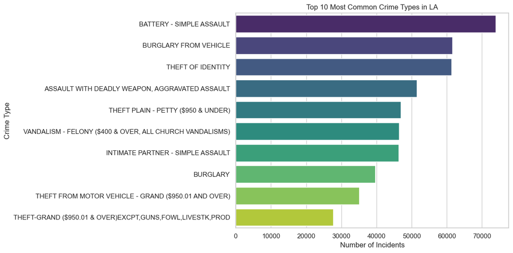

```python
# --- Top 10 Most Common Crimes ---
top_crimes = df_new['Crm Cd Desc'].value_counts().nlargest(10).reset_index()
top_crimes.columns = ['Crime Type', 'Count']

sns.set(style="whitegrid")
plt.figure(figsize=(12, 6))
sns.barplot(data=top_crimes, x='Count', y='Crime Type', hue='Crime Type', legend=False, palette='viridis')
plt.title('Top 10 Most Common Crime Types in LA')
plt.xlabel('Number of Incidents')
plt.ylabel('Crime Type')
plt.tight_layout()
plt.savefig('Common_Crime_Types.jpg')
plt.show()
```

### Top 10 Most Common Crimes

This bar chart shows the top 10 most frequently reported crime types in Los Angeles.

- The top categories include **Theft**, **Battery (Simple)**, **Vandalism**, and **Vehicle-Related Incidents**.
- The counts decline gradually from the most to least common among the top 10.

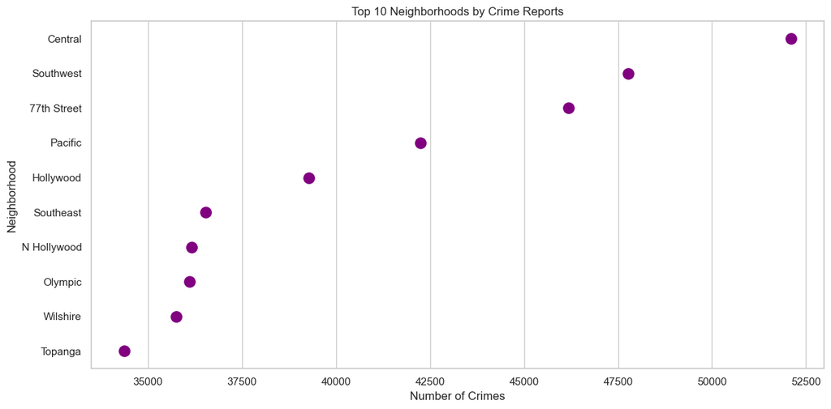

```python
# --- Crime Frequency by Neighborhood (Top 10 Areas) ---
top_areas = df_new['AREA NAME'].value_counts().nlargest(10).reset_index()
top_areas.columns = ['Neighborhood', 'Count']

plt.figure(figsize=(12, 6))
sns.stripplot(data=top_areas, x='Count', y='Neighborhood', size=12, color='purple')
plt.title('Top 10 Neighborhoods by Crime Reports')
plt.xlabel('Number of Crimes')
plt.ylabel('Neighborhood')
plt.grid(True, axis='x')
plt.tight_layout()
plt.show()
```

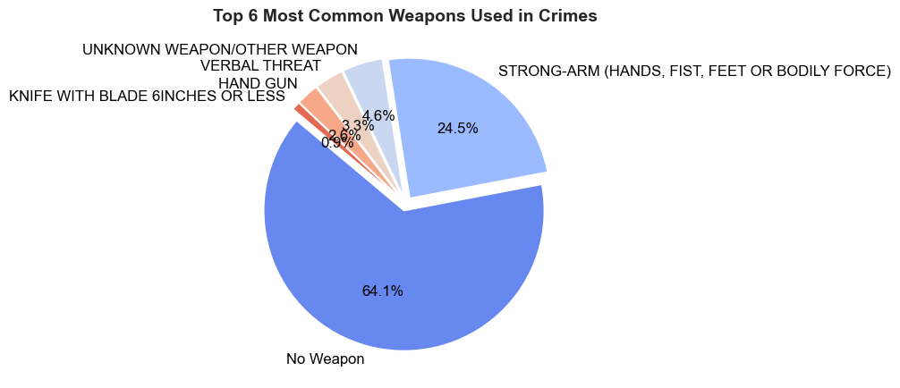

```python
# --- Weapon Usage Distribution ---
weapon_counts = df_new['Weapon Desc'].value_counts().nlargest(6)

plt.figure(figsize=(9, 9))
colors = sns.color_palette("coolwarm", len(weapon_counts))

wedges, texts, autotexts = plt.pie(
    weapon_counts.values,
    labels=weapon_counts.index,
    autopct='%1.1f%%',
    explode=[0.05] * len(weapon_counts),
    startangle=140,
    colors=colors,
    textprops={'fontsize': 12, 'color': 'black'},
    wedgeprops={'edgecolor': 'white', 'linewidth': 1}
)

# Enhance the title and layout
plt.title('Top 6 Most Common Weapons Used in Crimes', fontsize=14, weight='bold')
plt.tight_layout()
plt.show()
```

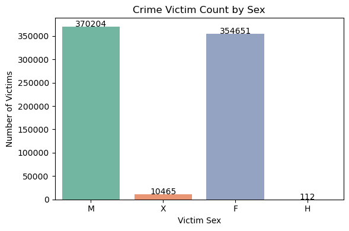

```python
# Countplot for Victim Sex
plt.figure(figsize=(6, 4))
sns.countplot(x="Vict Sex", data=df_new, hue="Vict Sex", palette="Set2", legend=False)

plt.title("Crime Victim Count by Sex")
plt.xlabel("Victim Sex")
plt.ylabel("Number of Victims")

for p in plt.gca().patches:
    plt.text(p.get_x() + p.get_width() / 2., p.get_height() + 5,
             f'{int(p.get_height())}', ha='center')

plt.tight_layout()
plt.show()
```

### Victim Count by Sex

This count plot shows how many victims are reported for each sex category.

- **Male victims** are the most common, followed by **female victims**.
- A small number of entries are labeled as **'X'**, which may represent non-binary, unknown, or undisclosed individuals.

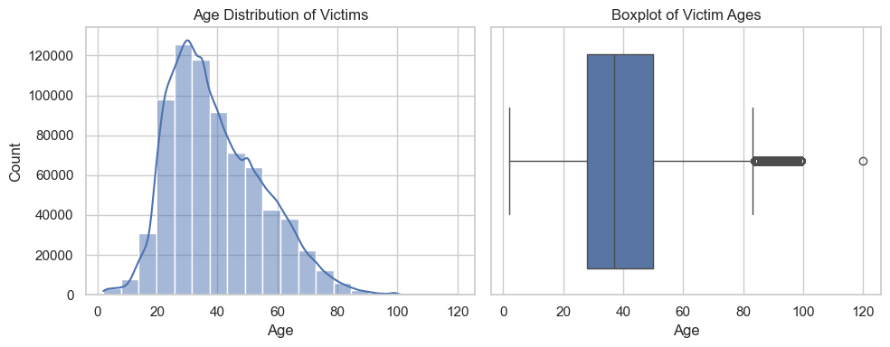

```python
#––––– Histogram & Boxplot for Victim Age –––––#
fig, axes = plt.subplots(1, 2, figsize=(10, 4))

sns.histplot(df_new["Vict Age"], bins=20, kde=True, ax=axes[0])
axes[0].set_title("Age Distribution of Victims")
axes[0].set_xlabel("Age")
axes[0].set_ylabel("Count")

sns.boxplot(x=df["Vict Age"], ax=axes[1])
axes[1].set_title("Boxplot of Victim Ages")
axes[1].set_xlabel("Age")

plt.tight_layout()
plt.show()
```

### Victim Age Distribution

We used a histogram and a boxplot to examine the spread of victim ages in the dataset.

**What it reveals:**  
The majority of crime victims are **young to middle-aged adults**. The distribution is **right-skewed**, indicating that older victims are less common. The outliers suggest rare cases involving elderly individuals.

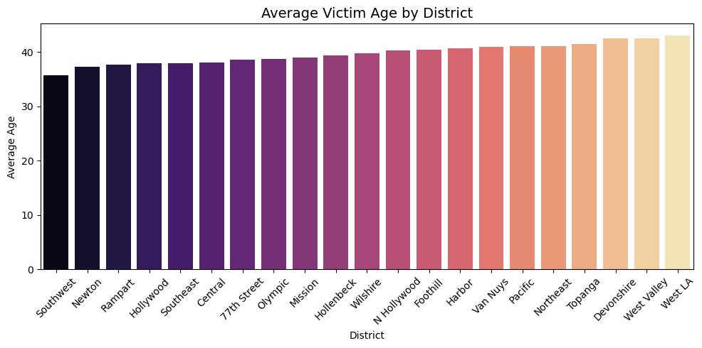

```python
# compute group means
age_by_district = df_new.groupby("AREA NAME")["Vict Age"].mean().sort_values().reset_index()
age_by_district.columns = ["District", "Average Age"]

plt.figure(figsize=(10, 5))
sns.barplot(
    data=age_by_district,
    x="District",
    hue='District',
    y="Average Age",
    palette="magma"
)
plt.title("Average Victim Age by District", fontsize=14)
plt.xlabel("District")
plt.ylabel("Average Age")
plt.xticks(rotation=45)
plt.tight_layout()
plt.show()
```

### Average Victim Age by District

This bar plot shows the **average age of victims** grouped by police district (`AREA NAME`).

**What it reveals:**  
There are **noticeable age-based patterns** among different parts of Los Angeles. Certain districts tend to have younger victims, possibly due to population density, nightlife activity, or socio-economic differences. Other areas with older average victims may experience more fraud, burglary, or white-collar crime.

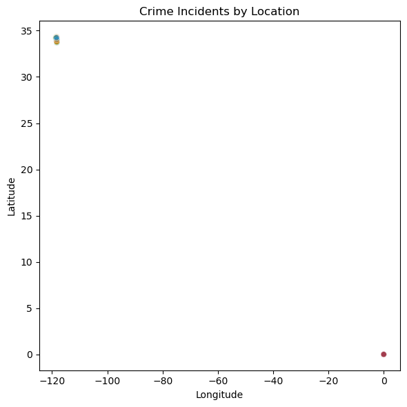

```python
plt.figure(figsize=(6,6))
sns.scatterplot(
    x="LON",
    y="LAT",
    data=df_cleaned,
    hue="Crm Cd Desc",
    palette="tab10",
    legend=False,
    alpha=0.6
)
plt.title("Crime Incidents by Location")
plt.xlabel("Longitude")
plt.ylabel("Latitude")
plt.tight_layout()
plt.show()
```

### Crime Incidents by Geographic Location

This scatter plot shows the geographic distribution of reported crimes using **longitude (`LON`) and latitude (`LAT`)**.

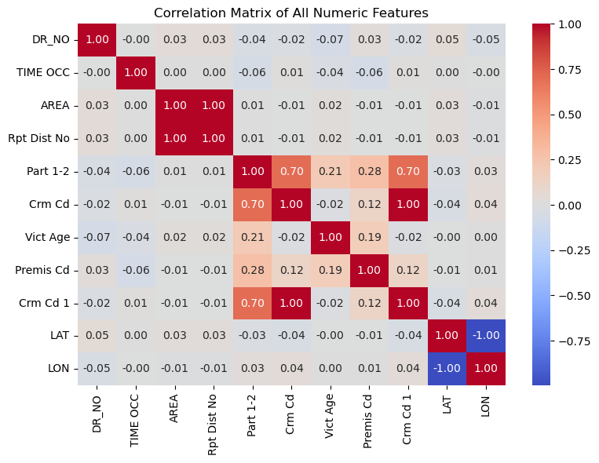

```python
# select numeric columns
num_cols = df.select_dtypes(include="number").columns

plt.figure(figsize=(8,6))
sns.heatmap(
    df_cleaned[num_cols].corr(),
    annot=True,
    fmt=".2f",
    cmap="coolwarm",
    center=0
)
plt.title("Correlation Matrix of All Numeric Features")
plt.tight_layout()
plt.show()
```

### Correlation Matrix of Numeric Features

This heatmap visualizes the **Pearson correlation coefficients** between all numeric features in the dataset.

#### Key Observations:

**What it reveals:**  
There are **redundant features** in the dataset that should be cleaned (e.g., drop one of the highly correlated crime or area codes).